#### Dr. Jesús Martí Gavilá. Departamento de Ingeniería Cartográfica, Geodesia y fotogrametría

# PRÁCTICA 9

# GOOGLE EARTH ENGINE PARA PYTHON

[figure not shown]

## Grado Tecnologías Interactivas | Tecnologías de la Información Geográfica

**Google Earth Engine**

Es una plataforma de geomática basada en la nube, con un catálogo de varios petabytes de imágenes satélites y conjuntos de datos geoespaciales, que permite a los usuarios visualizar y analizar de forma interactiva, cambios en la superficie del planeta mediante imágenes de satélite. Los científicos y las organizaciones sin ánimo de lucro utilizan Google Earth Engine para llevar a cabo estudios de teledetección remota, predecir brotes de enfermedades, gestionar recursos naturales, etc. Los estudiantes pueden acceder a esta información para participar en los debates y convertirse en científicos de datos.

## Tabla de Contenido

- Librerias y activación Google Earth Engine
- Mapa Indice de Severidad Normalizado (dNBR)
- Mapa Dual
- Tareas a realizar:
  - 1. Calcular índice SAVI
  - 2. Calcular índice EVI
  - 3. Mapa Dual

**Ejemplos:**

https://github.com/google/earthengine-api

https://github.com/gee-community/qgis-earthengine-plugin/tree/master/examples

https://github.com/giswqs/Awesome-GEE#python-api

**Documentación:**

https://python-visualization.github.io/folium

https://developers.google.com/earth-engine/guides

### ALUMNO:

# Estudio de Indices de Vegetación con Google Earth Engine.

## Casos de estudios

#### *Crear mapas de diferentes índices de vegetación del incendio ocurrido en la zona de Marxuquera (Gandia) el 6/08/2018* --------------------------------------------------------------------------------------------------------------------------------------------------------------------------------------------

La vegetación constituye uno de los componentes del medio físico de la mayor importancia para el equilibrio del medio ambiente. Por un lado, se trata de un recurso con un valor intrínseco (agricultura, pastos, bosques). Por otro lado, la cubierta vegetal juega un papel decisivo para el adecuado mantenimiento de otros muchos recursos (fauna, suelos, paisaje). Mediante el análisis multitemporal de imágenes de satélite, es posible hacer un seguimiento de la evolución de las diferentes comunidades vegetales y de los cultivos agrícolas. Los Índices de Vegetación son combinaciones de las bandas espectrales registradas por los satélites de Teledetección, cuya función es realzar la cubierta vegetal en función de su respuesta espectral y atenuar los detalles de otros componentes como el suelo, la iluminación, etc. Los Índices de Vegetación, son pues imágenes calculadas a partir de operaciones algebraicas entre distintas bandas espectrales. El resultado permite obtener una nueva imagen donde se destacan gráficamente determinados píxeles relacionados con parámetros de las coberturas vegetales: densidad, índice de área foliar y actividad clorofílica. (MappingGis)

### Previamente a la práctica asegurarse de tener instalado las librerias earthengine-api y folium en el enviroment de trabajo

## Librerías y Activación GEE

Cargar las librerías necesarias y activar la plataforma de GEE en la que previamente el usuario deberá haberse registrado.

```python
import folium
from folium import plugins
import ee
ee.Authenticate()
ee.Initialize()
```

```python
# Función de GEE predefinida para añadir capas con Folium

def add_ee_layer (self, ee_imagen, parametros, nombre):
    map_id = ee.Image(ee_imagen).getMapId(parametros)
    folium.raster_layers.TileLayer(
        tiles=map_id['tile_fetcher'].url_format,
        attr = 'Baldovi',
        name = nombre,
        overlay = True, # Permite la superposición
        control = True # Permite que aparezca la capa o no en el layer control
        ).add_to(self)

# Con esto creamos un método propio llamado addLayer que llamara a la función add_ee_layer
folium.Map.addLayer = add_ee_layer
```

## Mapa Indice de Severidad Normalizado dNBR

### Indice Normalizado de Área Quemada (NBR)

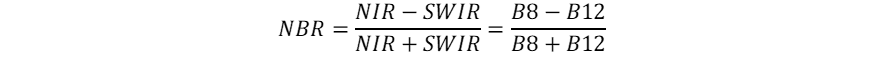

```python
# Colección de imágenes de Sentinel con una nubosidad inferior al 20% y la medía calculada de los pixels
sentinel_pre= (ee.ImageCollection('COPERNICUS/S2_SR_HARMONIZED')
                  .filterDate('2018-07-03', '2018-08-03')
                  .filter(ee.Filter.lt('CLOUDY_PIXEL_PERCENTAGE',20)).mean()) #el filtro de nubosidad varía según imagen

sentinel_post= (ee.ImageCollection('COPERNICUS/S2_SR_HARMONIZED')
                  .filterDate('2018-08-15', '2018-09-15')
                  .filter(ee.Filter.lt('CLOUDY_PIXEL_PERCENTAGE',20)).mean())

# Funciones de calculo NBR
def NBR(image):
    NBR = image.expression('float(NIR-SWIR2)/(NIR+SWIR2)',{
        'NIR' : image.select("B8").multiply(0.0001),
        'SWIR2' : image.select("B12").multiply(0.0001),
    })
    return NBR

# Parámetros de visualización de la imágen
vis_NBR ={
    'max': 1,
    'min': 0,
    # Paleta de colores standar de GEE
    'palette' : ['FFFFFF', 'CE7E45', 'DF923D', 'F1B555', 'FCD163', '99B718','74A901', '66A000', '529400', '3E8601', '207401', '056201',
               '004C00', '023B01', '012E01', '011D01', '011301']}

# Llamada a las funciones
NBR_pre = NBR(sentinel_pre)
NBR_post = NBR(sentinel_post)


# Exportar imagen a Google Drive. Configuración parámetros de salida
geometry = ee.Geometry.Rectangle([-0.40, 38.9, -0.20, 39.1]) #lat, lng, lat, lng
# Coordenadas geográficas minima y maxima de la imagen a exportar
task_config = {
        'region': geometry,
        'fileFormat': 'GeoTIFF',
        'fileNamePrefix': 'Marti_NBR_post',
        'folder':'gee-datos',
        'scale': 20,      # Resolución en metros del pixel
        'crs': 'EPSG:4326',
        'image': NBR_post,
        'description': 'Imagen procesada NBRpost'
    }
ee.batch.Export.image.toDrive(**task_config).start()

# Crear y añadir elementos al mapa
mapa_NBR = folium.Map(location=[39,-0.30], zoom_start = 12)
mapa_NBR.addLayer(NBR_pre,vis_NBR, "NBR_pre")
mapa_NBR.addLayer(NBR_post,vis_NBR, "NBR_post")

folium.LayerControl().add_to(mapa_NBR)

mapa_NBR
```

Make this Notebook Trusted to load map: File -> Trust Notebook

[interactive chart not shown]

### Indice de Severidad Normalizado (dNBR)

Es un índice normalizado que indica la pérdida de masa orgánica. La diferencia entre el NBR previo y posterior al incendio, obtenido de las imágenes satélite, se usa para calcular el diferencial NBR , con el que estimar la severidad del incendio. Un valor más alto de dNBR indica un daño más severo, mientras que las áreas con valores negativos de dNBR indican un creci-miento después de un incendio.

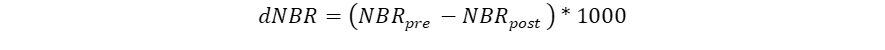

```python
# Funciones de calculo dNBR
def dNBR(pre,post):
    dNBR = pre.subtract(post).multiply(1000)
    return dNBR

# Parámetros de visualización de la imágen
vis_dNBR ={
    'max': 1000,
    'min': 100,
    # Paleta de colores standar de GEE
    'palette' : ['FFFFFF', 'CE7E45', 'DF923D', 'F1B555', 'FCD163', '99B718','74A901', '66A000', '529400', '3E8601', '207401', '056201',
               '004C00', '023B01', '012E01', '011D01', '011301']}
# Llamada a la funcion
imagen_dNBR= dNBR(NBR_pre,NBR_post)


mapa_dNBR = folium.Map(location=[39,-0.30], zoom_start = 12)
mapa_dNBR.addLayer(imagen_dNBR,vis_dNBR, "dNBR")
folium.LayerControl().add_to(mapa_dNBR)

mapa_dNBR
```

Make this Notebook Trusted to load map: File -> Trust Notebook

[interactive chart not shown]

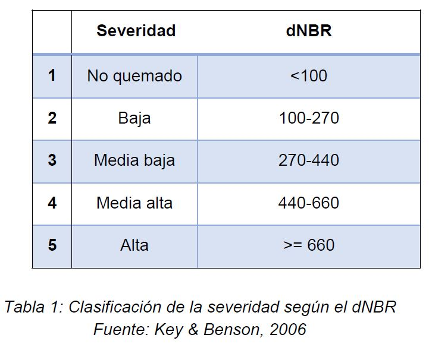

```python
# Ejemplo aplicación de intervalos a imagenes.
sld_intervalos = """
    <RasterSymbolizer>
        <ColorMap type="intervals" extended="false" >
            <ColorMapEntry color="#ffffff" quantity="100" label="No quemado"/>
            <ColorMapEntry color="#00ff00" quantity="270" label="Gravedad baja" />
            <ColorMapEntry color="#007f30" quantity="440" label="Gravedad Media baja" />
            <ColorMapEntry color="#FFA500" quantity="660" label="Gravedad Media Alta" />
            <ColorMapEntry color="#ff0000" quantity="1000" label="Gravedad Alta" />
        </ColorMap>
    </RasterSymbolizer>"""

# Crear y añadir elementos al mapa
mapa_intervalo = folium.Map(location=[39,-0.30], zoom_start=12)
mapa_intervalo.addLayer(imagen_dNBR.sldStyle(sld_intervalos),None,'SLD intervalos')
folium.LayerControl().add_to(mapa_intervalo)

mapa_intervalo
```

Make this Notebook Trusted to load map: File -> Trust Notebook

[interactive chart not shown]

## Mapa Dual (DualMap)

```python
# mapa dual
mapa_dual = folium.plugins.DualMap(location=[39,-0.30], tiles=None, zoom_start=12)

# Mapas Base
folium.TileLayer('OpenStreetMap').add_to(mapa_dual.m1)
folium.TileLayer('CartoDB Positron').add_to(mapa_dual.m2)

# Añadir capas a visualizar
mapa_dual.m1.addLayer(NBR_pre,vis_NBR, "NBR_pre")
mapa_dual.m2.addLayer(NBR_post,vis_NBR, "NBR_post")

# Añadir control de mapas
folium.LayerControl().add_to(mapa_dual)

# Guardar mapas en web
mapa_dual.save("Medio_Ambiente.html")

mapa_dual
```

Make this Notebook Trusted to load map: File -> Trust Notebook

[interactive chart not shown]

### Catálogo de recursos GEE

Enlace al catálogo de datos ofical de GEE

https://developers.google.com/earth-engine/datasets

## TAREA 1

### Realizar un mapa de Indice de Vegetación ajustado al suelo (SAVI) con imágenes SENTINEL 2A de la evolución del incendio ocurrido en Montitxelvo el 2/11/2023. Parámetros de localización:

- 1. Fechas Pre: '2023-09-15', '2023-10-15'
- 2. Fechas Post: '2023-11-15', '2023-12-15'
- 3. Zona a Exportar: Punto mínimo: [38.8,-0.4] Punto máximo [39.0,-0.15]
- 4. Punto Central : [38.9,-0.28]

### Calcular el SAVI_pre, SAVI_post y Guardar SAVI_post como Geotiff

El método Índice de vegetación ajustado al suelo (SAVI) es un índice de vegetación que intenta minimizar las influencias del brillo del suelo utilizando un factor de corrección de brillo del suelo. Esto con frecuencia se utiliza en regiones áridas en donde la cubierta de vegetación es baja y genera valores entre -1,0 y 1,0, siendo la vegetación sana 0 a 1. Su creador, Huete, agregó un factor de ajuste del suelo L a la ecuación de NDVI para corregir los efectos del ruido del suelo (color del suelo, humedad del suelo, variabilidad del suelo a través de la región, etc.), que tienden a afectar a los resultados.

### L = 0.428

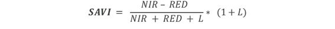

```python
sentinel_preT1= (ee.ImageCollection('COPERNICUS/S2_SR_HARMONIZED')
                  .filterDate('2023-09-15', '2023-10-15')
                  .filter(ee.Filter.lt('CLOUDY_PIXEL_PERCENTAGE',20)).mean()) #el filtro de nubosidad varía según imagen

sentinel_postT1= (ee.ImageCollection('COPERNICUS/S2_SR_HARMONIZED')
                  .filterDate('2023-11-15', '2023-12-15')
                  .filter(ee.Filter.lt('CLOUDY_PIXEL_PERCENTAGE',20)).mean())

def SAVI(image):
    SAVI = image.expression('float((NIR-RED)/(NIR+RED+L))*(1+L)',{
        'NIR' : image.select("B8").multiply(0.0001),
        'RED' : image.select("B4").multiply(0.0001),
        'L' : 0.428,
        '1' : 1,
    })
    return SAVI

# Parámetros de visualización de la imágen
vis_SAVI ={
    'max': 1,
    'min': 0,
    # Paleta de colores standar de GEE
    'palette' : ['FFFFFF', 'CE7E45', 'DF923D', 'F1B555', 'FCD163', '99B718','74A901', '66A000', '529400', '3E8601', '207401', '056201',
               '004C00', '023B01', '012E01', '011D01', '011301']}

# Llamada a las funciones
SAVI_pre = SAVI(sentinel_preT1)
SAVI_post = SAVI(sentinel_postT1)

# Exportar imagen a Google Drive. Configuración parámetros de salida
geometry = ee.Geometry.Rectangle([-0.40, 38.8, -0.15, 39.0]) #lat, lng, lat, lng
# Coordenadas geográficas minima y maxima de la imagen a exportar
task_config = {
        'region': geometry,
        'fileFormat': 'GeoTIFF',
        'fileNamePrefix': 'Tarea1_SAVI_post',
        'folder':'gee-datos',
        'scale': 20,      # Resolución en metros del pixel
        'crs': 'EPSG:4326',
        'image': SAVI_post,
        'description': 'Imagen procesada SAVIpost'
    }
ee.batch.Export.image.toDrive(**task_config).start()

# Funciones de calculo dNBR
def dSAVI(pre,post):
    dSAVI = pre.subtract(post).multiply(1000)
    return dSAVI
vis_dSAVI ={
    'max': 1000,
    'min': 100,
    # Paleta de colores standar de GEE
    'palette' : ['FFFFFF', 'CE7E45', 'DF923D', 'F1B555', 'FCD163', '99B718','74A901', '66A000', '529400', '3E8601', '207401', '056201',
               '004C00', '023B01', '012E01', '011D01', '011301']}

'''
imagen_dSAVI= dSAVI(SAVI_pre,SAVI_post)


mapa_dSAVI = folium.Map(location=[38.9,-0.28], zoom_start = 12)
mapa_dSAVI.addLayer(imagen_dSAVI,vis_dSAVI, "dSAVI")
folium.LayerControl().add_to(mapa_dSAVI)

mapa_dSAVI
'''

mapa_SAVI = folium.Map(location=[38.9,-0.28], zoom_start = 12)
mapa_SAVI.addLayer(SAVI_pre,vis_SAVI, "SAVI_pre")
mapa_SAVI.addLayer(SAVI_post,vis_SAVI, "SAVI_post")

folium.LayerControl().add_to(mapa_SAVI)

mapa_SAVI
```

Make this Notebook Trusted to load map: File -> Trust Notebook

[interactive chart not shown]

## TAREA 2

### L = 1.0

[figure not shown]

```python
sentinel_preT2= (ee.ImageCollection('LANDSAT/LC08/C02/T1_L2')
                  .filterDate('2023-09-15', '2023-10-15')
                  .filter(ee.Filter.lt('CLOUD_COVER',20)).mean()) #el filtro de nubosidad varía según imagen

sentinel_postT2= (ee.ImageCollection('LANDSAT/LC08/C02/T1_L2')
                  .filterDate('2023-11-15', '2023-12-15')
                  .filter(ee.Filter.lt('CLOUD_COVER',20)).mean())

def EVI(image):
    EVI = image.expression('float((NIR-RED)/(NIR+RED+L))*(1+L)',{
        'NIR' : image.select("SR_B5").multiply(0.0000275).add(-0.2),
        'RED' : image.select("SR_B4").multiply(0.0000275).add(-0.2),
        'BLUE' : image.select("SR_B2").multiply(0.0000275).add(-0.2),
        'L' : 1,
        'G' : 2.5,
        'C1' : 6,
        'C2' : 7.5,
    })
    return EVI

# Parámetros de visualización de la imágen
vis_EVI ={
    'max': 1,
    'min': 0,
    # Paleta de colores standar de GEE
    'palette' : ['FFFFFF', 'CE7E45', 'DF923D', 'F1B555', 'FCD163', '99B718','74A901', '66A000', '529400', '3E8601', '207401', '056201',
               '004C00', '023B01', '012E01', '011D01', '011301']}

# Llamada a las funciones
EVI_pre = EVI(sentinel_preT2)
EVI_post = EVI(sentinel_postT2)

# Exportar imagen a Google Drive. Configuración parámetros de salida
geometry = ee.Geometry.Rectangle([-0.40, 38.8, -0.15, 39.0]) #lat, lng, lat, lng
# Coordenadas geográficas minima y maxima de la imagen a exportar
task_config = {
        'region': geometry,
        'fileFormat': 'GeoTIFF',
        'fileNamePrefix': 'Tarea2_EVI_post',
        'folder':'gee-datos',
        'scale': 20,      # Resolución en metros del pixel
        'crs': 'EPSG:4326',
        'image': EVI_post,
        'description': 'Imagen procesada EVIpost'
    }
ee.batch.Export.image.toDrive(**task_config).start()

# Funciones de calculo dNBR
def dEVI(pre,post):
    dEVI = pre.subtract(post).multiply(1000)
    return dEVI

vis_dEVI ={
    'max': 1000,
    'min': 100,
    # Paleta de colores standar de GEE
    'palette' : ['FFFFFF', 'CE7E45', 'DF923D', 'F1B555', 'FCD163', '99B718','74A901', '66A000', '529400', '3E8601', '207401', '056201',
               '004C00', '023B01', '012E01', '011D01', '011301']}
'''
imagen_dEVI= dEVI(EVI_pre,EVI_post)


mapa_dEVI = folium.Map(location=[38.9,-0.28], zoom_start = 12)
mapa_dEVI.addLayer(imagen_dEVI,vis_dEVI, "dEVI")
folium.LayerControl().add_to(mapa_dEVI)

mapa_dEVI
'''

mapa_EVI = folium.Map(location=[38.9,-0.28], zoom_start = 12)
mapa_EVI.addLayer(EVI_pre,vis_EVI, "EVI_pre")
mapa_EVI.addLayer(EVI_post,vis_EVI, "EVI_post")

folium.LayerControl().add_to(mapa_EVI)

mapa_EVI
```

Make this Notebook Trusted to load map: File -> Trust Notebook

[interactive chart not shown]

## TAREA 3

### Realizar un mapa dual con los mapas obtenidos en la Tarea 1 y 2

Salvar el mapa como:

#### Medio_Ambiente_'Apellidos alumnos'.html

```python
# mapa dual
mapa_dualT3 = folium.plugins.DualMap(location=[38.9,-0.28], tiles=None, zoom_start=12)

# Mapas Base
folium.TileLayer('OpenStreetMap').add_to(mapa_dualT3.m1)
folium.TileLayer('CartoDB Positron').add_to(mapa_dualT3.m2)

# Añadir capas a visualizar
mapa_dualT3.m1.addLayer(SAVI_post,vis_SAVI, "SAVI_post")
mapa_dualT3.m2.addLayer(EVI_post,vis_EVI, "EVI_post")

# Añadir control de mapas
folium.LayerControl().add_to(mapa_dualT3)

# Guardar mapas en web
mapa_dualT3.save("Medio_Ambiente_Baldovi.html")

mapa_dualT3
```

Make this Notebook Trusted to load map: File -> Trust Notebook

[interactive chart not shown]